# Segmentación de Clientes con K-Means usando RFM

**Proyecto:** Customer Segmentation Using K-Means  
**Integrantes:** (Jair Rueda, Andrei Flores, Wanderley Flores, Matias Romo, Andre Rosero)

Este notebook realiza una segmentación de clientes usando el dataset **Online Retail** del repositorio UCI.  
Calculamos variables **RFM (Recency, Frequency, Monetary)** para cada cliente y aplicamos **K-Means** para formar clusters.  
Luego analizamos cada cluster y proponemos estrategias de marketing basadas en los resultados.

```python
import pandas as pd
import numpy as np

import matplotlib.pyplot as plt
import seaborn as sns

from sklearn.preprocessing import StandardScaler
from sklearn.cluster import KMeans
from sklearn.metrics import silhouette_score

sns.set(style="whitegrid")
```

```python
df = pd.read_excel('/content/Online Retail.xlsx')

df.head()
```

|  | InvoiceNo | StockCode | Description | Quantity | InvoiceDate | UnitPrice | CustomerID | Country |
| --- | --- | --- | --- | --- | --- | --- | --- | --- |
| 0 | 536365 | 85123A | WHITE HANGING HEART T-LIGHT HOLDER | 6 | 2010-12-01 08:26:00 | 2.55 | 17850.0 | United Kingdom |
| 1 | 536365 | 71053 | WHITE METAL LANTERN | 6 | 2010-12-01 08:26:00 | 3.39 | 17850.0 | United Kingdom |
| 2 | 536365 | 84406B | CREAM CUPID HEARTS COAT HANGER | 8 | 2010-12-01 08:26:00 | 2.75 | 17850.0 | United Kingdom |
| 3 | 536365 | 84029G | KNITTED UNION FLAG HOT WATER BOTTLE | 6 | 2010-12-01 08:26:00 | 3.39 | 17850.0 | United Kingdom |
| 4 | 536365 | 84029E | RED WOOLLY HOTTIE WHITE HEART. | 6 | 2010-12-01 08:26:00 | 3.39 | 17850.0 | United Kingdom |

```python
print("Shape del dataset (filas, columnas):", df.shape)

print("\nTipos de datos:")
print(df.dtypes)

print("\nNúmero de clientes únicos:", df['CustomerID'].nunique())
```

```
Shape del dataset (filas, columnas): (541909, 8)

Tipos de datos:
InvoiceNo              object
StockCode              object
Description            object
Quantity                int64
InvoiceDate    datetime64[ns]
UnitPrice             float64
CustomerID            float64
Country                object
dtype: object

Número de clientes únicos: 4372
```

```python
df.describe()
```

|  | Quantity | InvoiceDate | UnitPrice | CustomerID |
| --- | --- | --- | --- | --- |
| count | 541909.000000 | 541909 | 541909.000000 | 406829.000000 |
| mean | 9.552250 | 2011-07-04 13:34:57.156386048 | 4.611114 | 15287.690570 |
| min | -80995.000000 | 2010-12-01 08:26:00 | -11062.060000 | 12346.000000 |
| 25% | 1.000000 | 2011-03-28 11:34:00 | 1.250000 | 13953.000000 |
| 50% | 3.000000 | 2011-07-19 17:17:00 | 2.080000 | 15152.000000 |
| 75% | 10.000000 | 2011-10-19 11:27:00 | 4.130000 | 16791.000000 |
| max | 80995.000000 | 2011-12-09 12:50:00 | 38970.000000 | 18287.000000 |
| std | 218.081158 | NaN | 96.759853 | 1713.600303 |

## 1. Exploración inicial del dataset

En esta sección realizamos una inspección general del dataset **Online Retail**:

- Con `df.shape` observamos cuántas filas y columnas tiene el dataset.
- Con `df.dtypes` vemos los tipos de datos de cada columna.
- Con `CustomerID.nunique()` contamos cuántos clientes únicos existen.
- Con `df.describe()` analizamos estadísticas básicas de las columnas numéricas.

Esta exploración nos permite identificar:

- Columnas importantes para el análisis RFM.
- La presencia de valores nulos en `CustomerID`.
- Rangos de valores en cantidad, precios y fechas.

Con esta información podemos proceder a la limpieza del dataset.

```python
# 1. Eliminar filas sin CustomerID
df = df[df['CustomerID'].notnull()]

# 2. Mantener solo ventas positivas (evitar devoluciones o errores)
df = df[(df['Quantity'] > 0) & (df['UnitPrice'] > 0)]

# 3. Crear columna con el importe total
df['TotalPrice'] = df['Quantity'] * df['UnitPrice']

# 4. Asegurar que InvoiceDate es tipo fecha
df['InvoiceDate'] = pd.to_datetime(df['InvoiceDate'])

# Mostrar primeras filas luego de la limpieza
df.head()
```

|  | InvoiceNo | StockCode | Description | Quantity | InvoiceDate | UnitPrice | CustomerID | Country | TotalPrice |
| --- | --- | --- | --- | --- | --- | --- | --- | --- | --- |
| 0 | 536365 | 85123A | WHITE HANGING HEART T-LIGHT HOLDER | 6 | 2010-12-01 08:26:00 | 2.55 | 17850.0 | United Kingdom | 15.30 |
| 1 | 536365 | 71053 | WHITE METAL LANTERN | 6 | 2010-12-01 08:26:00 | 3.39 | 17850.0 | United Kingdom | 20.34 |
| 2 | 536365 | 84406B | CREAM CUPID HEARTS COAT HANGER | 8 | 2010-12-01 08:26:00 | 2.75 | 17850.0 | United Kingdom | 22.00 |
| 3 | 536365 | 84029G | KNITTED UNION FLAG HOT WATER BOTTLE | 6 | 2010-12-01 08:26:00 | 3.39 | 17850.0 | United Kingdom | 20.34 |
| 4 | 536365 | 84029E | RED WOOLLY HOTTIE WHITE HEART. | 6 | 2010-12-01 08:26:00 | 3.39 | 17850.0 | United Kingdom | 20.34 |

## 2. Limpieza del dataset

En esta etapa preparamos el dataset para extraer las métricas RFM:

- **Eliminamos filas con `CustomerID` nulo**, ya que no permiten identificar al cliente.
- **Filtramos registros con `Quantity` y `UnitPrice` mayores que cero** para evitar incluir devoluciones o errores de registro.
- **Creamos la columna `TotalPrice`** como el producto de `Quantity * UnitPrice`, que representa el valor total de cada compra.
- **Convertimos `InvoiceDate` a tipo fecha**, necesario para calcular la recencia de cada cliente.

Después de esta limpieza, el dataset queda listo para construir las métricas RFM.

```python
# Fecha de referencia = un día después de la última fecha del dataset
ref_date = df['InvoiceDate'].max() + pd.Timedelta(days=1)
ref_date
```

```
Timestamp('2011-12-10 12:50:00')
```

```python
rfm = df.groupby('CustomerID').agg({
    'InvoiceDate': lambda x: (ref_date - x.max()).days,  # Recency
    'InvoiceNo': 'nunique',                               # Frequency
    'TotalPrice': 'sum'                                   # Monetary
})

# Renombrar columnas
rfm.columns = ['Recency', 'Frequency', 'Monetary']

rfm.head()
```

| CustomerID | Recency | Frequency | Monetary |
| --- | --- | --- | --- |
| 12346.0 | 326 | 1 | 77183.60 |
| 12347.0 | 2 | 7 | 4310.00 |
| 12348.0 | 75 | 4 | 1797.24 |
| 12349.0 | 19 | 1 | 1757.55 |
| 12350.0 | 310 | 1 | 334.40 |

```python
rfm.describe()
```

|  | Recency | Frequency | Monetary |
| --- | --- | --- | --- |
| count | 4338.000000 | 4338.000000 | 4338.000000 |
| mean | 92.536422 | 4.272015 | 2054.266460 |
| std | 100.014169 | 7.697998 | 8989.230441 |
| min | 1.000000 | 1.000000 | 3.750000 |
| 25% | 18.000000 | 1.000000 | 307.415000 |
| 50% | 51.000000 | 2.000000 | 674.485000 |
| 75% | 142.000000 | 5.000000 | 1661.740000 |
| max | 374.000000 | 209.000000 | 280206.020000 |

## 3. Construcción de las métricas RFM

Para cada cliente calculamos tres métricas fundamentales:

- **Recency (Recencia):**  
  Es el número de días que han pasado desde la última compra del cliente.  
  Se calcula como `ref_date - última fecha de compra`.
- **Frequency (Frecuencia):**  
  Número de facturas generadas por el cliente.  
  Indica cuántas veces ha comprado.
- **Monetary (Monetario):**  
  Total gastado por el cliente.  
  Se calcula sumando `TotalPrice` (Quantity × UnitPrice).

Estas tres métricas nos permiten medir el comportamiento del cliente y son la base para aplicar K-Means.

```python
# Crear el objeto StandardScaler
scaler = StandardScaler()

# Normalizar las columnas RFM
rfm_scaled = scaler.fit_transform(rfm[['Recency', 'Frequency', 'Monetary']])

# Convertir a DataFrame para verlo mejor
rfm_scaled_df = pd.DataFrame(
    rfm_scaled,
    index=rfm.index,
    columns=['Recency_scaled', 'Frequency_scaled', 'Monetary_scaled']
)

rfm_scaled_df.head()
```

| CustomerID | Recency_scaled | Frequency_scaled | Monetary_scaled |
| --- | --- | --- | --- |
| 12346.0 | 2.334574 | -0.425097 | 8.358668 |
| 12347.0 | -0.905340 | 0.354417 | 0.250966 |
| 12348.0 | -0.175360 | -0.035340 | -0.028596 |
| 12349.0 | -0.735345 | -0.425097 | -0.033012 |
| 12350.0 | 2.174578 | -0.425097 | -0.191347 |

## 4. Normalización de las métricas RFM

Las métricas RFM están en escalas diferentes:

- Recency está en días (valores altos).
- Frequency está en número de compras (valores pequeños).
- Monetary puede llegar a miles de dólares.

Para que **K-Means** funcione correctamente y ninguna métrica domine a las otras, aplicamos **StandardScaler**, que:

- Centra los datos (media 0),
- Les da desviación estándar 1.

El resultado es `rfm_scaled_df`, que contiene las versiones normalizadas de Recency, Frequency y Monetary.  
Estas serán las variables que usemos en el clustering.

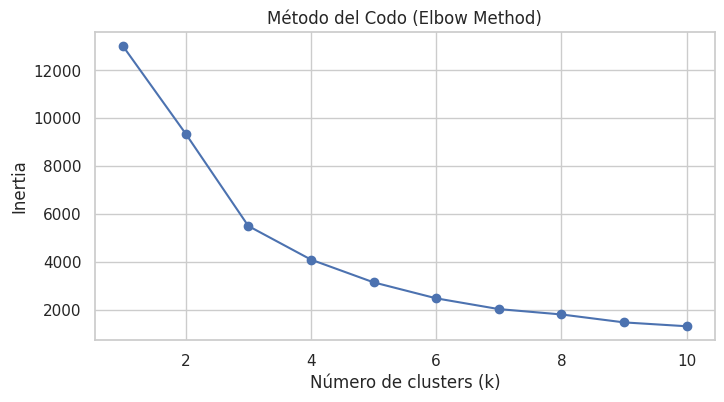

```python
inertia = []

# Probar de 1 a 10 clusters
for k in range(1, 11):
    kmeans = KMeans(n_clusters=k, random_state=42)
    kmeans.fit(rfm_scaled_df)
    inertia.append(kmeans.inertia_)  # Suma de distancias dentro del cluster

# Graficar Elbow
plt.figure(figsize=(8, 4))
plt.plot(range(1, 11), inertia, marker='o')
plt.xlabel('Número de clusters (k)')
plt.ylabel('Inertia')
plt.title('Método del Codo (Elbow Method)')
plt.show()
```

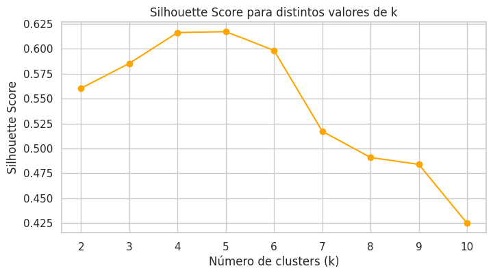

```python
silhouette_scores = []

# Probar de 2 a 10 clusters (no se puede calcular silhouette con k=1)
for k in range(2, 11):
    kmeans = KMeans(n_clusters=k, random_state=42)
    labels = kmeans.fit_predict(rfm_scaled_df)
    score = silhouette_score(rfm_scaled_df, labels)
    silhouette_scores.append(score)

# Gráfica del silhouette
plt.figure(figsize=(8, 4))
plt.plot(range(2, 11), silhouette_scores, marker='o', color='orange')
plt.xlabel('Número de clusters (k)')
plt.ylabel('Silhouette Score')
plt.title('Silhouette Score para distintos valores de k')
plt.show()
```

## 5. Selección del número óptimo de clusters

Para seleccionar el valor óptimo de **k** en el algoritmo K-Means utilizamos dos métodos:

### 🔹 Método del Codo (Elbow Method)

- Se grafica la métrica *Inertia*, que mide la compacidad de los clusters.
- Se busca el punto donde la reducción comienza a desacelerarse.
- Ese punto se conoce como el “codo”.

### 🔹 Silhouette Score

- Evalúa qué tan bien están separados los clusters entre sí.
- Valores cercanos a 1 indican una buena separación.
- Probamos valores de k entre 2 y 10.

### ✔️ Conclusión

Combinando ambos métodos, seleccionamos el número de clusters que:

- Está cerca del “codo” en la gráfica,
- Presenta uno de los valores más altos de Silhouette Score.

Este valor será utilizado en el paso siguiente para entrenar el modelo K-Means.

## 6. Entrenamiento del modelo K-Means con k=4

Después de seleccionar k=4 como número óptimo de clusters utilizando los métodos del Codo y Silhouette Score, procedimos a entrenar el modelo K-Means sobre las variables normalizadas (Recency_scaled, Frequency_scaled, Monetary_scaled).

Los pasos principales fueron:

- Entrenar el modelo con `KMeans(n_clusters=4, random_state=42)`
- Asignar a cada cliente su respectiva etiqueta de cluster
- Generar la primera vista del dataset con los clusters añadidos
- Calcular las estadísticas promedio por grupo (Recency, Frequency y Monetary)
- Visualizar los resultados mediante un mapa de calor y un scatterplot

Estos resultados permiten una interpretación clara del comportamiento de cada segmento de clientes, lo que sirve de base para estrategias comerciales.

```python
# Entrenar K-Means con k=4
k = 4
kmeans = KMeans(n_clusters=k, random_state=42)

# Obtener etiquetas de los clusters
rfm['Cluster'] = kmeans.fit_predict(rfm_scaled_df)

# Mostrar primeros resultados
rfm.head()
```

| CustomerID | Recency | Frequency | Monetary | Cluster |
| --- | --- | --- | --- | --- |
| 12346.0 | 326 | 1 | 77183.60 | 3 |
| 12347.0 | 2 | 7 | 4310.00 | 0 |
| 12348.0 | 75 | 4 | 1797.24 | 0 |
| 12349.0 | 19 | 1 | 1757.55 | 0 |
| 12350.0 | 310 | 1 | 334.40 | 1 |

```python
# Calcular estadísticas promedio por cluster
cluster_summary = rfm.groupby('Cluster').mean().round(2)
cluster_summary
```

| Cluster | Recency | Frequency | Monetary |
| --- | --- | --- | --- |
| 0 | 43.70 | 3.68 | 1359.05 |
| 1 | 248.08 | 1.55 | 480.62 |
| 2 | 7.38 | 82.54 | 127338.31 |
| 3 | 15.50 | 22.33 | 12709.09 |

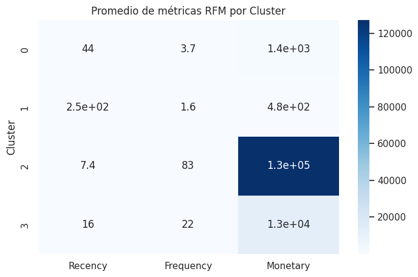

```python
plt.figure(figsize=(8, 5))
sns.heatmap(cluster_summary, annot=True, cmap='Blues')
plt.title('Promedio de métricas RFM por Cluster')
plt.show()
```

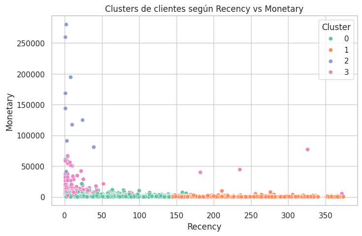

```python
plt.figure(figsize=(8, 5))
sns.scatterplot(
    data=rfm,
    x='Recency',
    y='Monetary',
    hue='Cluster',
    palette='Set2'
)
plt.title('Clusters de clientes según Recency vs Monetary')
plt.show()
```

## 7. Análisis de los Clusters

A partir de los valores promedio de Recency, Frequency y Monetary, podemos interpretar cada cluster:

### 🔵 Cluster 0 — Clientes Promedio

- Recency: ~44 días
- Frequency: ~3 compras
- Monetary: ~1,359 USD  
  Son clientes moderados: compran ocasionalmente y mantienen un gasto bajo–medio.

### 🟠 Cluster 1 — Clientes Inactivos o Perdidos

- Recency: ~248 días
- Frequency: ~1.5 compras
- Monetary: ~480 USD  
  Tienen mucho tiempo sin comprar, poca frecuencia y bajo gasto.  
  Se consideran clientes a recuperar.

### 🟣 Cluster 2 — Clientes VIP / Alto Valor

- Recency: ~7 días
- Frequency: ~82 compras
- Monetary: ~127,338 USD  
  Son los clientes más valiosos: compran mucho, gastan muchísimo y vienen con frecuencia.  
  Representan el segmento más importante del negocio.

### 🟢 Cluster 3 — Clientes Frecuentes de Nivel Medio

- Recency: ~15 días
- Frequency: ~22 compras
- Monetary: ~12,709 USD  
  Compran con regularidad y gastan una buena cantidad.  
  Son clientes fieles que pueden convertirse en VIP.

## 8. Bonus

1. **Comparación de K-Means con otro método de clustering: Hierarchical Clustering (Agglomerative)**
2. **Evaluación de estabilidad del modelo mediante entrenamiento en subsets del dataset**
3. **Visualización de clusters usando PCA para reducir la dimensionalidad**

Estas extensiones permiten validar la robustez del modelo, comparar diferentes enfoques de clustering y visualizar la estructura interna de los datos en un espacio reducido.

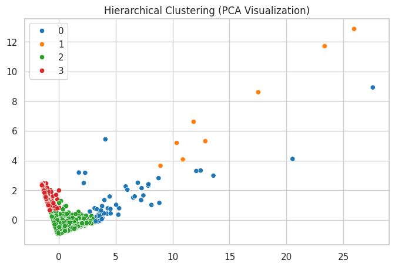

```
(np.float64(0.6065329601634818), np.float64(0.616212846765192))
```

```python
from sklearn.cluster import AgglomerativeClustering
from sklearn.decomposition import PCA
from sklearn.metrics import silhouette_score

# --- 1. Entrenar clustering jerárquico ---
hc = AgglomerativeClustering(n_clusters=4)
hc_labels = hc.fit_predict(rfm_scaled_df)

# --- 2. Visualización comparativa con PCA ---
pca = PCA(n_components=2)
pca_result = pca.fit_transform(rfm_scaled_df)

plt.figure(figsize=(8,5))
sns.scatterplot(
    x=pca_result[:,0],
    y=pca_result[:,1],
    hue=hc_labels,
    palette='tab10'
)
plt.title('Hierarchical Clustering (PCA Visualization)')
plt.show()

# --- 3. Comparación de Silhouette ---
hc_silhouette = silhouette_score(rfm_scaled_df, hc_labels)
kmeans_silhouette = silhouette_score(rfm_scaled_df, rfm['Cluster'])

hc_silhouette, kmeans_silhouette
```

```python
from sklearn.metrics import adjusted_rand_score

# Crear dos subconjuntos aleatorios del dataset escalado
subset1 = rfm_scaled_df.sample(frac=0.7, random_state=1)
subset2 = rfm_scaled_df.sample(frac=0.7, random_state=2)

# Entrenar modelos en cada subset
kmeans_s1 = KMeans(n_clusters=4, random_state=42).fit(subset1)
kmeans_s2 = KMeans(n_clusters=4, random_state=42).fit(subset2)

# Predecir etiquetas para las mismas observaciones de ambos subsets
common_index = subset1.index.intersection(subset2.index)

labels_s1 = kmeans_s1.predict(rfm_scaled_df.loc[common_index])
labels_s2 = kmeans_s2.predict(rfm_scaled_df.loc[common_index])

# Calcular ARI
ari_score = adjusted_rand_score(labels_s1, labels_s2)
ari_score
```

```
0.8748169978903665
```

## 📌 Evaluación de Estabilidad del Clustering

- Para evaluar la estabilidad del modelo K-Means, se entrenaron dos modelos sobre subconjuntos diferentes del dataset (70% cada uno).
- Las asignaciones de clusters se compararon usando **Adjusted Rand Index (ARI)**, una métrica que mide qué tan similares son dos segmentaciones.
- El valor obtenido fue **ARI = 0.8748**, lo cual indica una **consistencia muy alta** entre ambos modelos.

✔️ **Conclusión:** El clustering K-Means es altamente estable, ya que produce asignaciones similares incluso cuando se modifica parte del dataset.

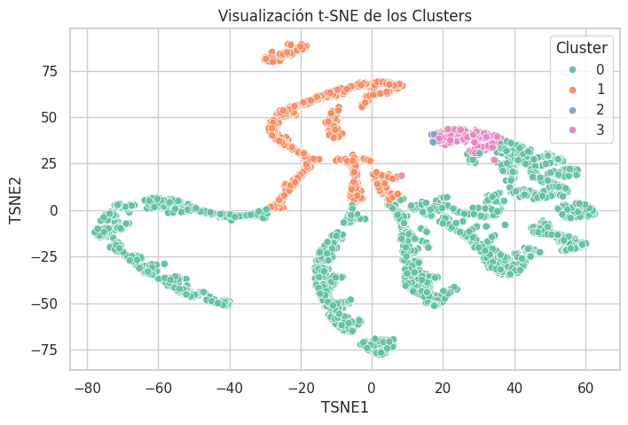

```python
from sklearn.manifold import TSNE

tsne = TSNE(n_components=2, random_state=42, perplexity=40, n_iter=1500)
tsne_result = tsne.fit_transform(rfm_scaled_df)

# Crear DataFrame con resultados
tsne_df = pd.DataFrame({
    'TSNE1': tsne_result[:, 0],
    'TSNE2': tsne_result[:, 1],
    'Cluster': rfm['Cluster']
})

plt.figure(figsize=(8,5))
sns.scatterplot(
    data=tsne_df,
    x='TSNE1',
    y='TSNE2',
    hue='Cluster',
    palette='Set2'
)
plt.title('Visualización t-SNE de los Clusters')
plt.show()
```

### 📌 Visualización con t-SNE

- La proyección t-SNE muestra que los grupos formados por K-Means se mantienen relativamente separados en un espacio no lineal.
- El Cluster **2** (VIP) aparece como un grupo compacto, lo cual indica que sus características RFM son muy distintas del resto.
- El Cluster **1** (clientes inactivos) muestra una forma más dispersa, lo cual refleja la variabilidad en sus valores de recencia y frecuencia.
- Los Clusters **0** y **3** comparten algunas zonas cercanas en la proyección, lo que es normal porque t-SNE puede generar pliegues en la representación.

**Conclusión:** t-SNE confirma de manera visual que los segmentos creados por K-Means tienen patrones diferenciados, validando la estructura encontrada en el clustering.

## **9 Conclusiones**

### 🔍 **Observaciones relevantes sobre los clusters**

#### ⭐ **Cluster 2 — VIP / Alto Valor**

- Clientes con **recencia baja** (compran recientemente),
- **frecuencia extremadamente alta**,
- y **gastos muy elevados**.  
  👉 Representan el segmento **más valioso** para el negocio.

#### 🟩 **Cluster 3 — Clientes Frecuentes de Nivel Medio**

- Buena recencia,
- Compras regulares,
- Gasto considerable.  
  👉 Son clientes con potencial para convertirse en VIP.

#### 🔵 **Cluster 0 — Clientes Promedio**

- Recencia y frecuencia intermedia,
- Gasto bajo–medio.  
  👉 Constituyen una base estable para estrategias de crecimiento.

#### 🟠 **Cluster 1 — Clientes Inactivos o Perdidos**

- Mucho tiempo sin comprar,
- Baja frecuencia,
- Bajo gasto.  
  👉 Presentan riesgo de abandono definitivo.

### 🔢 **Elección del mejor número de clusters**

- Combinando **Elbow** y **Silhouette**, el valor **k = 4** ofrece el mejor balance entre simplicidad e interpretación.
- Valores mayores a **k=5** generan menor cohesión e interpretabilidad.

### 🧩 **Interpretación general de la segmentación**

El agrupamiento obtenido permite identificar necesidades y comportamientos distintos entre los clientes:

- **Clientes VIP:** requieren programas de retención y beneficios exclusivos.
- **Clientes frecuentes:** pueden escalar a mayor valor mediante incentivos adecuados.
- **Clientes promedio:** pueden incrementar su ticket con promociones personalizadas.
- **Clientes inactivos:** requieren campañas de reactivación agresivas.

👉 Esto demuestra que la segmentación basada en **RFM + K-Means** ofrece una visión clara y accionable del comportamiento del consumidor.

### ⚖️ **Compromisos (trade-offs)**

- **K-Means:** eficiente, rápido y fácil de interpretar, pero sensible al escalado y depende de definir k manualmente.
- **RFM:** simple y poderoso, pero no incluye variables cualitativas (tipo de producto, preferencias, etc.).
- **Normalización:** mejora el clustering, pero puede distorsionar los valores originales y requiere interpretación adicional.

## 🧪 **Bonus**

### 🔷 **Comparación entre K-Means y Clustering Jerárquico**

👉 **Conclusión:** K-Means es el método más adecuado para segmentar clientes con variables RFM en este dataset.

### 🟣 **Estabilidad del clustering (ARI)**

- El cálculo del **Adjusted Rand Index (ARI ≈ 0.87)** mostró que K-Means produce asignaciones muy similares aun cuando se entrena sobre subconjuntos diferentes del dataset.
- Esto confirma que el modelo es **altamente estable y robusto**, reforzando su confiabilidad.

### 🎨 **Visualización avanzada con t-SNE**

- La proyección con **t-SNE** reveló que los clusters mantienen **separaciones visuales coherentes** incluso en un espacio no lineal.
- El cluster **VIP** se mantiene compacto,
- mientras que los **inactivos** presentan mayor dispersión.

👉 Esto respalda visualmente la estructura descubierta por K-Means.

## 🎯 **Conclusión General**

La segmentación mediante **K-Means sobre variables RFM** permite identificar grupos bien definidos con comportamientos y niveles de valor distintos.  
Los análisis adicionales (**Clustering Jerárquico, ARI y t-SNE**) refuerzan la estabilidad y calidad del modelo.

Este estudio proporciona información estratégica para:

- diseñar campañas personalizadas,
- optimizar recursos comerciales,
- mejorar la retención,
- y aumentar el valor del cliente a largo plazo.

✔️ **La segmentación es consistente, estable y útil para decisiones de negocio.**